clc;clear;

workingpath='/Volumes/WD_D/gufei/monkey_data/campwater';

cd(workingpath);

files=dir('*top.csv');

alldata=cell(1,length(files));

% middle point

m=zeros(1,length(files));

conditions=cell(1,length(files));

for f=1:length(files)

% load data

filename=files(f).name;

% replace _ with -

conditions{f}=strrep(filename(1:end-8),'_','-');

% 从第二行第一列读取数据

data=csvread(filename,1,0);

m(f)=mean([min(data(:,2)) max(data(:,2))]);

disp(filename)

disp([min(data(:,2)) mean([min(data(:,2)) max(data(:,2))]) max(data(:,2)) min(data(:,3)) mean([min(data(:,3)) max(data(:,3))]) max(data(:,3))])

% y is reversed

data(:,3)=140-data(:,3);

% 绘制轨迹

% monkeyt(data(:,2),data(:,3),0.1,0.001);

% 查看分布情况

% length(data(data(:,2)>100,3));

% length(data(data(:,2)<=100,3));

%

% length(data(data(:,2)<=90,3));

% length(data(data(:,2)>=110,3));

%

% length(data(data(:,2)<=80,3));

% length(data(data(:,2)>=120,3));

% max(data(:,2));

% min(data(:,2));

% mean([max(data(:,2)),min(data(:,2))]);

%保存到cell中

alldata{f}=data;

end

吲哚_L_20201001_top.csv

56.2673 125.4151 194.5630 64.4272 98.1361 131.8450

吲哚_R_20200930_top.csv

54.2995 122.3422 190.3850 67.1329 102.1270 137.1210

异戊酸_L_20200929_top.csv

53.1225 121.6917 190.2610 66.0996 99.3773 132.6550

异戊酸_R_20200926_top.csv

95.9620 148.8110 201.6600 79.4112 108.2996 137.1880

白桃_L_20201003_top.csv

55.9635 124.9228 193.8820 56.6824 95.3447 134.0070

白桃_R_20201004_top.csv

56.4970 125.4910 194.4850 55.4538 92.7459 130.0380

香蕉_L_20201008_top.csv

66.3677 128.3604 190.3530 60.8057 95.2284 129.6510

香蕉_R_20201009_top.csv

56.7712 139.0971 221.4230 51.9538 95.0794 138.2050

## Scale

for f=1:length(files)

data=alldata{f};

mid=m(f);

minvalue=min(data(:,2));

maxvalue=max(data(:,2));

data(data(:,2)<=mid,2)=(data(data(:,2)<=mid,2)-minvalue)*100/(mid-minvalue);

data(data(:,2)>mid,2)=100+(data(data(:,2)>mid,2)-mid)*100/(maxvalue-mid);

alldata{f}=data;

end

## 绘制轨迹

% for f=1:length(files)

% data=alldata{f};

% figure;

% % 绘制轨迹

% % monkeyt(data(:,2),data(:,3),0.1,0.001);

% monkeyt(data(:,2),data(:,3),0,0);

% title(conditions{f});

% end

## 整体的直方图

interval=5;

for f=1:length(files)

data=alldata{f};

% chisq test

disp(conditions{f})

for i=0:10:20

cutl=100-i;

cutr=100+i;

disp([cutl cutr])

% chit-chisquare test

[pvalue,st]=chit(data,cutl,cutr)

end

figure;

% x方向的分布

subplot(1,2,1)

hist(data(:,2),interval/2:interval:200-interval/2);

line([100 100],get(gca,'Ylim'),'linestyle',':')

title('x')

% y方向的分布

subplot(1,2,2)

hist(data(:,3));

title('y')

suptitle(conditions{f});

end

吲哚-L-20201001

100 100

pvalue = 0

st =

chi2stat: 2.4300e+04  
df: 1  
edges: [0 100 200]  
O: [69045 22007]  
E: [45526 45526]

90 110

pvalue = 0

st =

chi2stat: 2.6821e+04  
df: 1  
edges: [0 100 200]  
O: [67539 19283]  
E: [43411 43411]

80 120

pvalue = 0

st =

chi2stat: 2.8201e+04  
df: 1  
edges: [0 100 200]  
O: [66179 17578]  
E: [4.1878e+04 4.1878e+04]

吲哚-R-20200930

100 100

pvalue = 0

st =

chi2stat: 9.2685e+03  
df: 1  
edges: [0 100 200]  
O: [60440 31283]  
E: [4.5862e+04 4.5862e+04]

90 110

pvalue = 0

st =

chi2stat: 9.4008e+03  
df: 1  
edges: [0 100 200]  
O: [55282 27402]  
E: [41342 41342]

80 120

pvalue = 0

st =

chi2stat: 8.9671e+03  
df: 1  
edges: [0 100 200]  
O: [50503 24559]  
E: [37531 37531]

异戊酸-L-20200929

100 100

pvalue = 0

st =

chi2stat: 2.2411e+04  
df: 1  
edges: [0 100 200]  
O: [67536 22593]  
E: [4.5064e+04 4.5064e+04]

90 110

pvalue = 0

st =

chi2stat: 2.2715e+04  
df: 1  
edges: [0 100 200]  
O: [64180 20359]  
E: [4.2270e+04 4.2270e+04]

80 120

pvalue = 0

st =

chi2stat: 2.1880e+04  
df: 1  
edges: [0 100 200]  
O: [59330 18155]  
E: [3.8742e+04 3.8742e+04]

异戊酸-R-20200926

100 100

pvalue = 0

st =

chi2stat: 8.0411e+03  
df: 1  
edges: [0 100 200]  
O: [63352 35201]  
E: [4.9276e+04 4.9276e+04]

90 110

pvalue = 0

st =

chi2stat: 7.5419e+03  
df: 1  
edges: [0 100 200]  
O: [61033 34229]  
E: [47631 47631]

80 120

pvalue = 0

st =

chi2stat: 7.5911e+03  
df: 1  
edges: [0 100 200]  
O: [56677 30894]  
E: [4.3786e+04 4.3786e+04]

白桃-L-20201003

100 100

pvalue = 0

st =

chi2stat: 1.0551e+04  
df: 1  
edges: [0 100 200]  
O: [61755 30548]  
E: [4.6152e+04 4.6152e+04]

90 110

pvalue = 0

st =

chi2stat: 1.3551e+04  
df: 1  
edges: [0 100 200]  
O: [60145 25982]  
E: [4.3064e+04 4.3064e+04]

80 120

pvalue = 0

st =

chi2stat: 1.5703e+04  
df: 1  
edges: [0 100 200]  
O: [58676 22888]  
E: [40782 40782]

白桃-R-20201004

100 100

pvalue = 0

st =

chi2stat: 1.5235e+04  
df: 1  
edges: [0 100 200]  
O: [69967 30788]  
E: [5.0378e+04 5.0378e+04]

90 110

pvalue = 0

st =

chi2stat: 1.7402e+04  
df: 1  
edges: [0 100 200]  
O: [66798 26504]  
E: [46651 46651]

80 120

pvalue = 0

st =

chi2stat: 1.9189e+04  
df: 1  
edges: [0 100 200]  
O: [64957 23709]  
E: [44333 44333]

香蕉-L-20201008

100 100

pvalue = 0

st =

chi2stat: 2.1324e+04  
df: 1  
edges: [0 100 200]  
O: [68432 24029]  
E: [4.6230e+04 4.6230e+04]

90 110

pvalue = 0

st =

chi2stat: 2.3610e+04  
df: 1  
edges: [0 100 200]  
O: [65810 20633]  
E: [4.3222e+04 4.3222e+04]

80 120

pvalue = 0

st =

chi2stat: 2.4477e+04  
df: 1  
edges: [0 100 200]  
O: [63603 18715]  
E: [41159 41159]

香蕉-R-20201009

100 100

pvalue = 9.0705e-58

st =

chi2stat: 256.6827  
df: 1  
edges: [0 100 200]  
O: [47511 42699]  
E: [45105 45105]

90 110

pvalue = 4.4497e-43

st =

chi2stat: 189.3312  
df: 1  
edges: [0 100 200]  
O: [45167 41125]  
E: [43146 43146]

80 120

pvalue = 1.5867e-19

st =

chi2stat: 81.6965  
df: 1  
edges: [0 100 200]  
O: [42157 39573]  
E: [40865 40865]

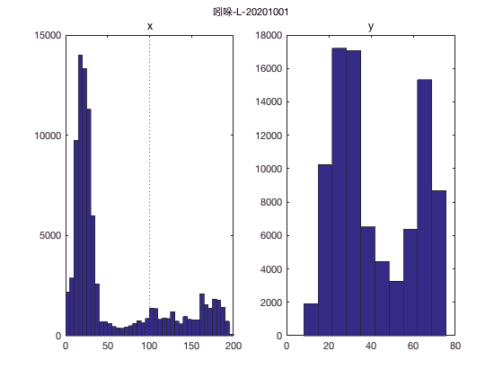

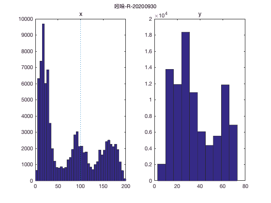

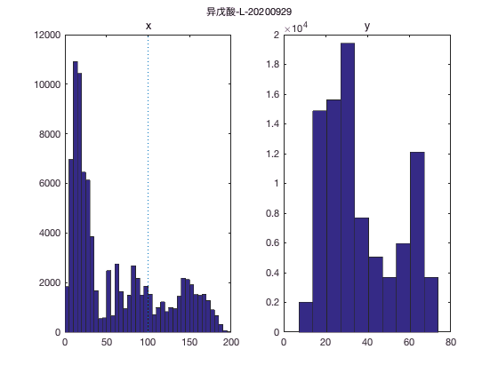

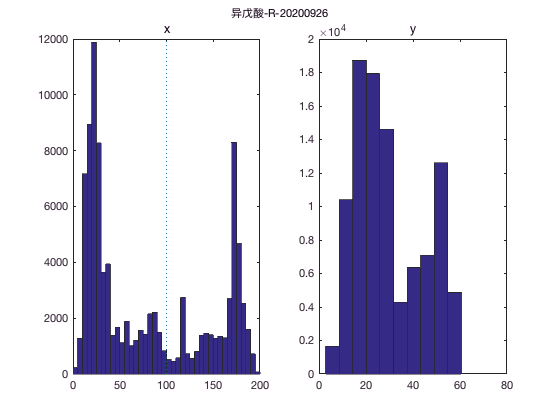

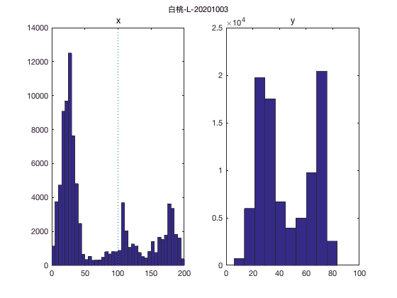

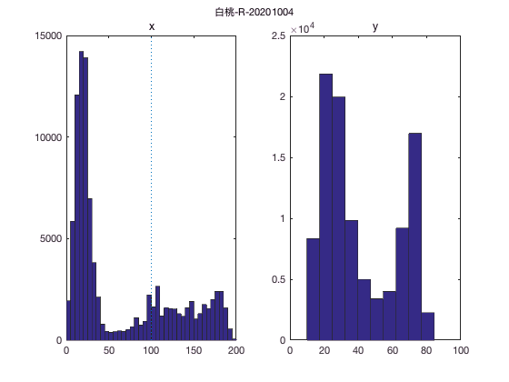

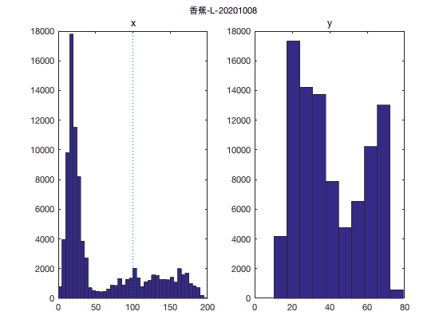

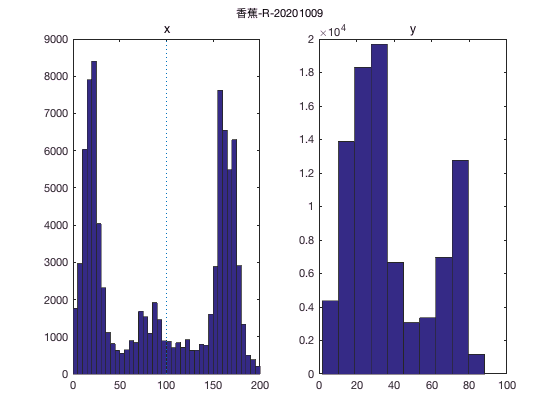

## 合并4个条件

tic;

interval=10;

% concatenate all the data

data=cell2mat(alldata');

expect=zeros(3,2);

% chisq test

disp('all days');

all days

for i=0:10:20

cutl=100-i;

cutr=100+i;

disp([cutl cutr])

[pvalue,st]=chit(data,cutl,cutr)

expect(i/10+1,:)=st.O;

end

100 100

pvalue = 0

st =

chi2stat: 9.6766e+04  
df: 1  
edges: [0 100 200]  
O: [508038 239148]  
E: [373593 373593]

90 110

pvalue = 0

st =

chi2stat: 1.0426e+05  
df: 1  
edges: [0 100 200]  
O: [485954 215517]  
E: [3.5074e+05 3.5074e+05]

80 120

pvalue = 0

st =

chi2stat: 1.0752e+05  
df: 1  
edges: [0 100 200]  
O: [462082 196071]  
E: [3.2908e+05 3.2908e+05]

figure;

subplot(1,2,1)

hist(data(:,2),interval/2:interval:200-interval/2);

line([100 100],get(gca,'Ylim'),'linestyle',':')

title('x')

% y方向的分布

subplot(1,2,2)

hist(data(:,3));

title('y')

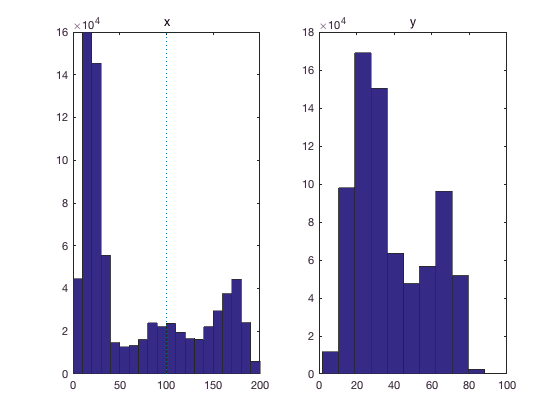

## 绘制热图

xx=data(:,2);

yy=data(:,3);

% sigma = 0.1;

gridSize = 100;

x=linspace(0,200,gridSize+1);

y=linspace(0,100,gridSize+1);

gridEval = zeros(length(x)-1,length(y)-1);

% 计算每个网格中点的频数

for cnt_x=1:length(x)-1

for cnt_y=1:length(y)-1

x_ind=xx>x(cnt_x) & xx<=x(cnt_x+1);

xy_ind=yy(x_ind)>y(cnt_y) & yy(x_ind)<=y(cnt_y+1);

gridEval(cnt_y, cnt_x)=length(yy(xy_ind));

end

end

% % 计算每个点处的高斯函数

% for i = 1:length(x)-1

% for j = 1:length(y)-1

% %calculate a Gaussian function on the grid with each point in the center and add them up

% gridEval(j,i) = gridEval(j,i) + sum(exp(-(((x(i)-xx).^2)./(2*sigma.^2) + ((y(j)-yy).^2)./(2*sigma.^2))));

% end

% end

% 绘制热图

figure;

surf((x(1:end-1)+ x(2:end))/2,(y(1:end-1)+y(2:end))/2,gridEval); view(2); shading interp;

% 增加z轴会变成三维的

% axis([0 200 0 100 0 100]);

axis([0 200 0 100])

h1 = gca; % 保存句柄，以便后面添加边框

set(gca, 'CLim', [0 400]);

% 添加标注

% title(['平滑散点图, \sigma = ' num2str(sigma) ', 网格数： ' num2str(gridSize) ' x' num2str(gridSize)],'Fontsize',14);

title(['网格数： ' num2str(gridSize) ' x' num2str(gridSize)]);

xlabel('x','Fontsize',14);

ylabel('y','Fontsize',14);

% 添加颜色条

colormap jet

colorbar;

ylabel('Intensity','Fontsize',14);

% 添加黑色的边框

axes(h1);

line(get(gca,'xlim'),repmat(min(get(gca,'ylim')),1,2),'color',[0 0 0],'linewidth',1);

line(get(gca,'xlim'),repmat(max(get(gca,'ylim')),1,2),'color',[0 0 0],'linewidth',2);

line(repmat(min(get(gca,'xlim')),1,2),get(gca,'ylim'),'color',[0 0 0],'linewidth',2);

line(repmat(max(get(gca,'xlim')),1,2),get(gca,'ylim'),'color',[0 0 0],'linewidth',1);

set(gcf,'color',[1 1 1],'paperpositionmode','auto');

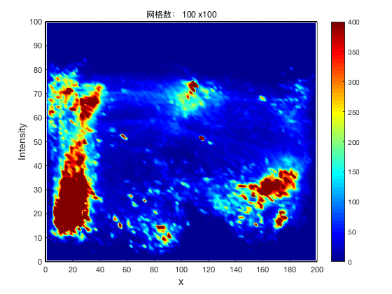

toc;

时间已过 35.916231 秒。

## 合并odor两个条件

tic;

interval=10;

for odor=2:2:length(conditions)

data=alldata{odor};

data(:,2)=200-data(:,2);

data=[alldata{odor-1};data];

% chisq test

disp(conditions{odor-1})

for i=0:10:20

cutl=100-i;

cutr=100+i;

disp([cutl cutr])

[pvalue,st]=chit(data,cutl,cutr,expect(i/10+1,:))

end

figure;

subplot(1,2,1)

hist(data(:,2),interval/2:interval:200-interval/2);

line([100 100],get(gca,'Ylim'),'linestyle',':')

title('x')

% y方向的分布

subplot(1,2,2)

hist(data(:,3));

title('y')

t=conditions{odor-1};

suptitle(t(1:end-9));

% 绘制热图

xx=data(:,2);

yy=data(:,3);

% sigma = 0.1;

gridSize = 100;

x=linspace(0,200,gridSize+1);

y=linspace(0,100,gridSize+1);

gridEval = zeros(length(x)-1,length(y)-1);

% 计算每个网格中点的频数

for cnt_x=1:length(x)-1

for cnt_y=1:length(y)-1

x_ind=xx>x(cnt_x) & xx<=x(cnt_x+1);

xy_ind=yy(x_ind)>y(cnt_y) & yy(x_ind)<=y(cnt_y+1);

gridEval(cnt_y, cnt_x)=length(yy(xy_ind));

end

end

% % 计算每个点处的高斯函数

% for i = 1:length(x)-1

% for j = 1:length(y)-1

% %calculate a Gaussian function on the grid with each point in the center and add them up

% gridEval(j,i) = gridEval(j,i) + sum(exp(-(((x(i)-xx).^2)./(2*sigma.^2) + ((y(j)-yy).^2)./(2*sigma.^2))));

% end

% end

% 绘制热图

figure;

surf((x(1:end-1)+ x(2:end))/2,(y(1:end-1)+y(2:end))/2,gridEval); view(2); shading interp;

% 增加z轴会变成三维的

% axis([0 200 0 100 0 100]);

axis([0 200 0 100])

h1 = gca; % 保存句柄，以便后面添加边框

set(gca, 'CLim', [0 400]);

% 添加标注

% title(['平滑散点图, \sigma = ' num2str(sigma) ', 网格数： ' num2str(gridSize) ' x' num2str(gridSize)],'Fontsize',14);

title([t(1:end-9) ' 网格数： ' num2str(gridSize) ' x' num2str(gridSize)]);

xlabel('x','Fontsize',14);

ylabel('y','Fontsize',14);

% 添加颜色条

colormap jet

colorbar;

ylabel('Intensity','Fontsize',14);

% 添加黑色的边框

axes(h1);

line(get(gca,'xlim'),repmat(min(get(gca,'ylim')),1,2),'color',[0 0 0],'linewidth',1);

line(get(gca,'xlim'),repmat(max(get(gca,'ylim')),1,2),'color',[0 0 0],'linewidth',2);

line(repmat(min(get(gca,'xlim')),1,2),get(gca,'ylim'),'color',[0 0 0],'linewidth',2);

line(repmat(max(get(gca,'xlim')),1,2),get(gca,'ylim'),'color',[0 0 0],'linewidth',1);

set(gcf,'color',[1 1 1],'paperpositionmode','auto');

end

吲哚-L-20201001

100 100

pvalue = 0

st =

chi2stat: 1.4417e+04  
df: 1  
edges: [0 100 200]  
O: [100328 82447]  
E: [1.2428e+05 5.8500e+04]

90 110

pvalue = 0

st =

chi2stat: 1.4016e+04  
df: 1  
edges: [0 100 200]  
O: [94941 74565]  
E: [1.1743e+05 5.2078e+04]

80 120

pvalue = 0

st =

chi2stat: 1.2983e+04  
df: 1  
edges: [0 100 200]  
O: [90738 68081]  
E: [1.1151e+05 4.7314e+04]

异戊酸-L-20200929

100 100

pvalue = 0

st =

chi2stat: 1.5904e+04  
df: 1  
edges: [0 100 200]  
O: [102737 85945]  
E: [1.2829e+05 6.0390e+04]

90 110

pvalue = 0

st =

chi2stat: 1.7870e+04  
df: 1  
edges: [0 100 200]  
O: [98409 81392]  
E: [1.2456e+05 5.5241e+04]

80 120

pvalue = 0

st =

chi2stat: 1.9072e+04  
df: 1  
edges: [0 100 200]  
O: [90224 74832]  
E: [1.1588e+05 4.9172e+04]

白桃-L-20201003

100 100

pvalue = 0

st =

chi2stat: 3.5692e+04  
df: 1  
edges: [0 100 200]  
O: [92543 100515]  
E: [1.3127e+05 6.1791e+04]

90 110

pvalue = 0

st =

chi2stat: 3.7124e+04  
df: 1  
edges: [0 100 200]  
O: [86649 92780]  
E: [1.2430e+05 5.5127e+04]

80 120

pvalue = 0

st =

chi2stat: 3.8723e+04  
df: 1  
edges: [0 100 200]  
O: [82385 87845]  
E: [1.1952e+05 5.0713e+04]

香蕉-L-20201008

100 100

pvalue = 0

st =

chi2stat: 4.2994e+03  
df: 1  
edges: [0 100 200]  
O: [111131 71540]  
E: [1.2420e+05 5.8467e+04]

90 110

pvalue = 0

st =

chi2stat: 4.4075e+03  
df: 1  
edges: [0 100 200]  
O: [106935 65800]  
E: [1.1966e+05 5.3070e+04]

80 120

pvalue = 0

st =

chi2stat: 4.1970e+03  
df: 1  
edges: [0 100 200]  
O: [103176 60872]  
E: [1.1518e+05 4.8872e+04]

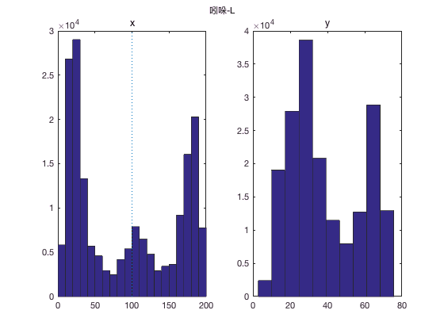

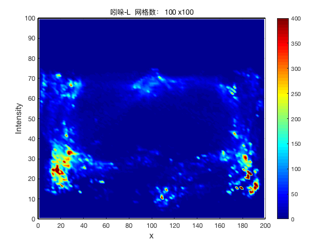

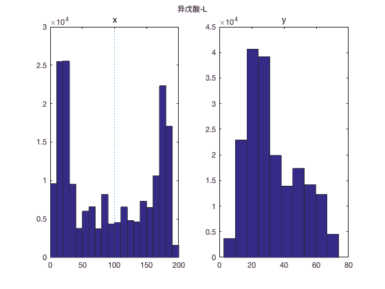

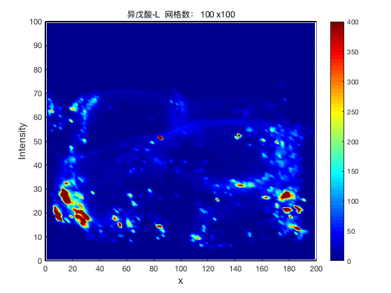

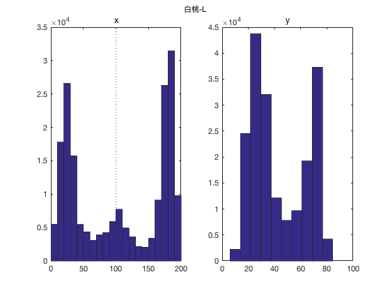

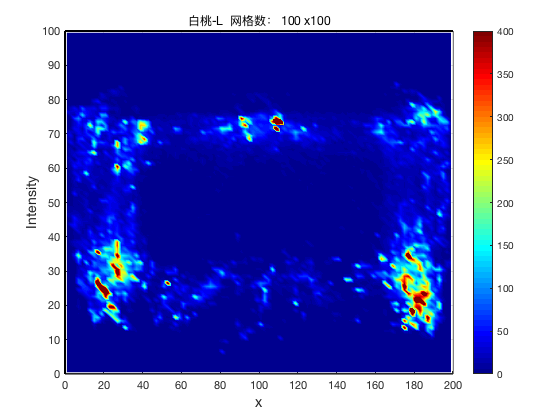

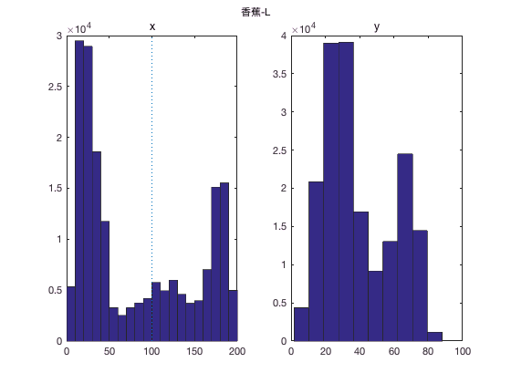

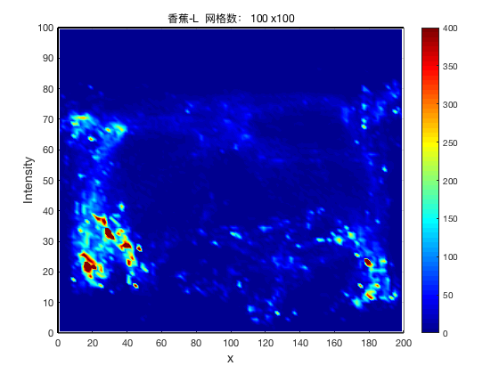

toc;

时间已过 49.485101 秒。

## 合并odor两个条件的（只取前面一段时间）

interval=10;

timeint=10;%minute

p1=1;

p2=timeint*60*1000/40;

% 1和3合并为1的方向

for odor=2:2:length(conditions)

data=alldata{odor};

data(:,2)=200-data(:,2);

data=[alldata{odor-1}(p1:p2,:);data(p1:p2,:)];

data=data(data(:,2)<=50|data(:,2)>=150,:);

% chisq test

for i=0

cutl=100-i;

cutr=100+i;

disp([cutl cutr])

[pvalue,st]=chit(data,cutl,cutr)

end

figure;

subplot(1,2,1)

hist(data(:,2),interval/2:interval:200-interval/2);

line([100 100],get(gca,'Ylim'),'linestyle',':')

title('x')

% y方向的分布

subplot(1,2,2)

hist(data(:,3));

title('y')

t=conditions{odor-1};

suptitle(t(1:end-9));

end

100 100

pvalue = 0

st =

chi2stat: 2.0486e+03  
df: 1  
edges: [0 100 200]  
O: [13861 7280]  
E: [1.0570e+04 1.0570e+04]

100 100

pvalue = 7.1215e-112

st =

chi2stat: 505.1724  
df: 1  
edges: [0 100 200]  
O: [9962 7032]  
E: [8497 8497]

100 100

pvalue = 7.8686e-69

st =

chi2stat: 307.4447  
df: 1  
edges: [0 100 200]  
O: [10112 12764]  
E: [11438 11438]

100 100

pvalue = 0

st =

chi2stat: 5.3879e+03  
df: 1  
edges: [0 100 200]  
O: [14894 4636]  
E: [9765 9765]

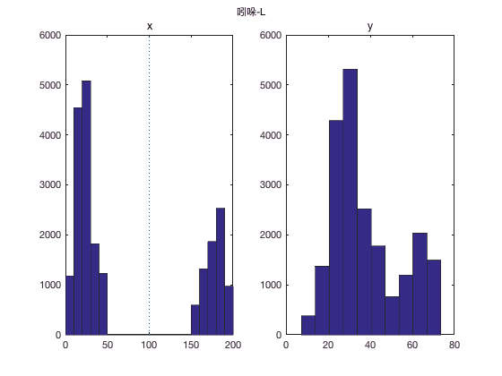

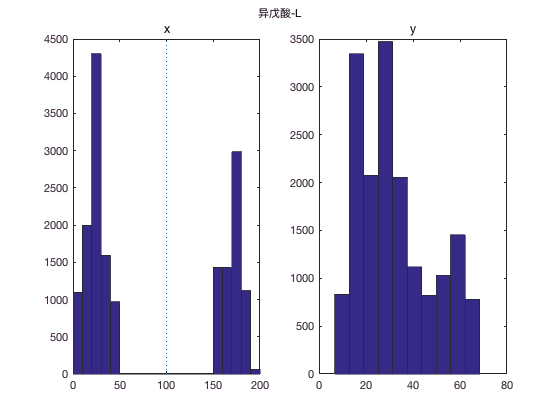

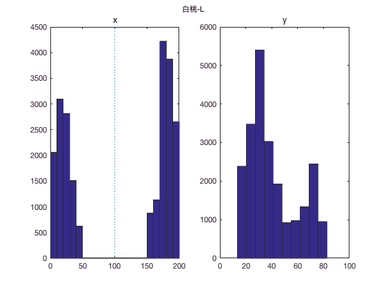

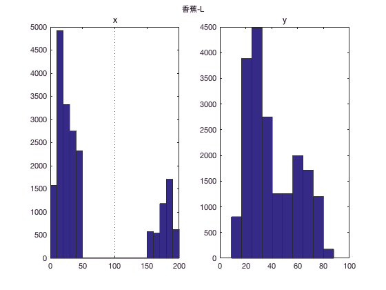

## 分时段的分布直方图

timeint=9.1;%minute

p=round(timeint*60*1000/40);

interval=5;

% plot each day

for f=1:length(files)

data=alldata{f};

l=length(data(:,2));

plots=ceil(l/p);

disp('===========================')

disp(conditions{f})

disp('===========================')

for j=0:10:50

timelab=zeros(1,l);

leftright=timelab;

cutl=100-j;

cutr=100+j;

leftright(data(:,2)<cutl)=1;

leftright(data(:,2)>cutl)=2;

for i=1:plots

timelab(p*(i-1)+1:min(p*i,l))=i;

end

timelab(leftright==0)=[];

leftright(leftright==0)=[];

[tbl,chi2,pvalue] = crosstab(timelab,leftright);

disp('-------------')

disp([num2str(cutl) '-' num2str(cutr)])

disp(tbl)

disp(chi2)

disp(pvalue)

disp('-------------')

% barplot

percenttbl=tbl./sum(tbl,2);

figure;

set(gca,'YDir','reverse')

title(conditions{f})

end

set(gcf,'position',[1280,720,ceil(plots/2)*400,2*300]);

% subplot each bin

for i=1:plots

subplot(2,ceil(plots/2),i)

line([100 100],get(gca,'Ylim'),'linestyle',':')

% disp('-------------')

% disp([num2str(p*(i-1)+1) '-' num2str(min(p*i,l))])

%

% chisq test

for j=0%:10:20

cutl=100-j;

cutr=100+j;

% disp([cutl cutr])

[pvalue,st]=chit(data(p*(i-1)+1:min(p*i,l),:),cutl,cutr);

end

% disp('-------------')

title({[num2str(p*(i-1)+1) '-' num2str(min(p*i,l))];[num2str(cutl) '-' num2str(cutr) ' : ' num2str(st.O)]})

end

suptitle({conditions{f};''});

end

===========================

吲哚-L-20201001

===========================

-------------

100-100

9534 4116  
10483 3167  
10264 3386  
10462 3188  
10507 3143  
11145 2505  
6650 2502

593.6181

5.5504e-125

-------------

-------------

90-110

9280 4370  
10310 3340  
9979 3671  
10162 3488  
10294 3356  
10973 2677  
6541 2611

615.7630

9.2752e-130

-------------

-------------

80-120

9009 4641  
10167 3483  
9847 3803  
9772 3878  
10089 3561  
10821 2829  
6474 2678

666.1149

1.2636e-140

-------------

-------------

70-130

8838 4812  
10028 3622  
9736 3914  
9547 4103  
9986 3664  
10696 2954  
6412 2740

691.8327

3.5470e-146

-------------

-------------

60-140

8685 4965  
9924 3726  
9597 4053  
9456 4194  
9866 3784  
10593 3057  
6361 2791

708.4771

9.0398e-150

-------------

-------------

50-150

8442 5208  
9815 3835  
9238 4412  
9344 4306  
9760 3890  
10490 3160  
6307 2845

819.2666

1.0578e-173

-------------

===========================

吲哚-R-20200930

===========================

-------------

100-100

6972 6678  
8265 5385  
8686 4964  
10848 2802  
7868 5782  
10315 3335  
7486 2337

4.1050e+03

0

-------------

-------------

90-110

6204 7446  
6858 6792  
8311 5339  
10264 3386  
7110 6540  
9743 3907  
6792 3031

4.5050e+03

0

-------------

-------------

80-120

5582 8068  
5900 7750  
7318 6332  
9328 4322  
6577 7073  
9223 4427  
6575 3248

4.5477e+03

0

-------------

-------------

70-130

4764 8886  
5635 8015  
6796 6854  
8814 4836  
6359 7291  
8913 4737  
6487 3336

5.0214e+03

0

-------------

-------------

60-140

4377 9273  
5397 8253  
6511 7139  
8638 5012  
6132 7518  
8734 4916  
6390 3433

5.4404e+03

0

-------------

-------------

50-150

4030 9620  
5161 8489  
6283 7367  
8477 5173  
5796 7854  
8466 5184  
6313 3510

5.8129e+03

0

-------------

===========================

异戊酸-L-20200929

===========================

-------------

100-100

6558 7092  
10935 2715  
9849 3801  
10996 2654  
11674 1976  
10699 2951  
6825 1404

6.9171e+03

0

-------------

-------------

90-110

5377 8273  
10315 3335  
9460 4190  
10739 2911  
11570 2080  
10296 3354  
6423 1806

8.7912e+03

0

-------------

-------------

80-120

4585 9065  
9669 3981  
8682 4968  
9508 4142  
11510 2140  
9095 4555  
6281 1948

9.0603e+03

0

-------------

-------------

70-130

3433 10217  
9564 4086  
8383 5267  
9212 4438  
11470 2180  
8933 4717  
5904 2325

1.1725e+04

0

-------------

-------------

60-140

3025 10625  
9479 4171  
8252 5398  
6086 7564  
11432 2218  
8710 4940  
5521 2708

1.3177e+04

0

-------------

-------------

50-150

2663 10987  
7408 6242  
8116 5534  
5884 7766  
11395 2255  
8533 5117  
5370 2859

1.2961e+04

0

-------------

===========================

异戊酸-R-20200926

===========================

-------------

100-100

6577 7073  
8217 5433  
7943 5707  
8440 5210  
9371 4279  
9888 3762  
10355 3295  
2561 442

3.7792e+03

0

-------------

-------------

90-110

6196 7454  
7908 5742  
7241 6409  
8126 5524  
9322 4328  
9504 4146  
10194 3456  
2542 461

4.3421e+03

0

-------------

-------------

80-120

5601 8049  
6887 6763  
5914 7736  
7435 6215  
9269 4381  
8975 4675  
10064 3586  
2532 471

6.3055e+03

0

-------------

-------------

70-130

5128 8522  
6633 7017  
5522 8128  
7132 6518  
9004 4646  
8618 5032  
9119 4531  
2521 482

5.9010e+03

0

-------------

-------------

60-140

4676 8974  
6451 7199  
5158 8492  
6835 6815  
8844 4806  
8293 5357  
8689 4961  
2505 498

6.2144e+03

0

-------------

-------------

50-150

4322 9328  
6202 7448  
4909 8741  
6564 7086  
8772 4878  
7944 5706  
7242 6408  
2486 517

5.8385e+03

0

-------------

===========================

白桃-L-20201003

===========================

-------------

100-100

7377 6273  
7759 5891  
7240 6410  
9466 4184  
11216 2434  
10070 3580  
8627 1776

5.7989e+03

0

-------------

-------------

90-110

7138 6512  
7152 6498  
7068 6582  
9376 4274  
11071 2579  
9838 3812  
8502 1901

6.2004e+03

0

-------------

-------------

80-120

6871 6779  
6863 6787  
6959 6691  
9238 4412  
10926 2724  
9388 4262  
8431 1972

6.2378e+03

0

-------------

-------------

70-130

6697 6953  
6721 6929  
6848 6802  
9165 4485  
10847 2803  
9208 4442  
8383 2020

6.3697e+03

0

-------------

-------------

60-140

6561 7089  
6619 7031  
6749 6901  
9102 4548  
10760 2890  
9146 4504  
8325 2078

6.4454e+03

0

-------------

-------------

50-150

6417 7233  
6523 7127  
6640 7010  
9029 4621  
10676 2974  
8837 4813  
8276 2127

6.4435e+03

0

-------------

===========================

白桃-R-20201004

===========================

-------------

100-100

8641 5009  
8774 4876  
9634 4016  
10633 3017  
8349 5301  
10102 3548  
9385 4265  
4449 756

2.0905e+03

0

-------------

-------------

90-110

8424 5226  
8617 5033  
9462 4188  
9840 3810  
8203 5447  
9865 3785  
8374 5276  
4013 1192

1.3247e+03

7.4961e-282

-------------

-------------

80-120

8049 5601  
8485 5165  
9311 4339  
9596 4054  
8102 5548  
9663 3987  
8262 5388  
3489 1716

999.7953

1.3336e-211

-------------

-------------

70-130

7719 5931  
8391 5259  
9120 4530  
9495 4155  
7983 5667  
9464 4186  
8157 5493  
3425 1780

1.0278e+03

1.1786e-217

-------------

-------------

60-140

7629 6021  
8310 5340  
8899 4751  
9346 4304  
7845 5805  
9381 4269  
8064 5586  
3392 1813

974.9189

3.1590e-206

-------------

-------------

50-150

7523 6127  
8228 5422  
8711 4939  
9263 4387  
7753 5897  
9257 4393  
7980 5670  
3357 1848

938.8411

1.9628e-198

-------------

===========================

香蕉-L-20201008

===========================

-------------

100-100

9987 3663  
9487 4163  
9162 4488  
9905 3745  
10489 3161  
10544 3106  
8858 1703

1.1665e+03

8.6266e-249

-------------

-------------

90-110

9373 4277  
9243 4407  
8661 4989  
9437 4213  
10032 3618  
10327 3323  
8737 1824

1.4028e+03

6.0868e-300

-------------

-------------

80-120

8561 5089  
9077 4573  
8273 5377  
9288 4362  
9799 3851  
10174 3476  
8431 2130

1.5636e+03

0

-------------

-------------

70-130

8330 5320  
8969 4681  
7846 5804  
9149 4501  
9567 4083  
9998 3652  
8002 2559

1.4547e+03

3.4238e-311

-------------

-------------

60-140

8196 5454  
8875 4775  
7612 6038  
9004 4646  
9437 4213  
9866 3784  
7806 2755

1.4455e+03

3.3289e-309

-------------

-------------

50-150

8076 5574  
8785 4865  
7406 6244  
8832 4818  
9321 4329  
9750 3900  
7732 2829

1.5196e+03

0

-------------

===========================

香蕉-R-20201009

===========================

-------------

100-100

6310 7340  
6726 6924  
9219 4431  
7116 6534  
8399 5251  
7847 5803  
1894 6416

5.0353e+03

0

-------------

-------------

90-110

5847 7803  
6106 7544  
8737 4913  
6735 6915  
8224 5426  
7631 6019  
1887 6423

4.7451e+03

0

-------------

-------------

80-120

5334 8316  
5296 8354  
8167 5483  
6048 7602  
8022 5628  
7409 6241  
1881 6429

4.6848e+03

0

-------------

-------------

70-130

4578 9072  
4228 9422  
7518 6132  
5688 7962  
7889 5761  
7154 6496  
1876 6434

5.2471e+03

0

-------------

-------------

60-140

4307 9343  
3794 9856  
7020 6630  
5420 8230  
7774 5876  
7010 6640  
1870 6440

5.3161e+03

0

-------------

-------------

50-150

4079 9571  
3539 10111  
6808 6842  
5237 8413  
7661 5989  
6861 6789  
1805 6505

5.5177e+03

0

-------------